### Pearson Correlation Analysis

Using pseudobulk on Seurat Cluster to form gene x accession matrices for each cluster. We also import phenotype metadata (accessions and their respective phenotype val). Then using linear pearson correlation R values and its respective adj p values to filter it out.

Since scatterplots look very 0 inflated, and most heatmaps show positve r-vals, we are suspecting we need to try out a different kind of normalisation (LMM) that might improve the results. There are not a lot of cell specific genes showing up through this pipeline compared to the XGB ML model. We tried Logit regression as well, however Flowering Time, Plant Dry Weight, and Lattitude shows good results

Heatmap Examples and Work related to pipeline can be found here: https://docs.google.com/presentation/d/1PbmYhv_nslxEZFPF7JLtSIL2ANF63-WbFdWRNgYipP4/edit?usp=sharing

Pseudocode: 1. Load seurat cluster 2. for each cluster: 3. Pseudobulk by ecotype 4. save in pseudobulk_df_list 5. Set thresholds to resemble normalised distribution 6. for each cluster: 7. Filter according to threshold 8. save in pseudobulk_df_list_filtered 9. for each cluster: 10. Normalise 11. save in pseudobulk_df_list_normalised 12. Import phenotype df from 1001 genomes 13. for each cluster: 14. list of common accessions between cluster matrix and phenotype df, align and filter out accessions with each other 15. save filtered accession phenotype and cluster matrices to Phenotype_list and Cluster_list respectively 16. for each cluster: 17. take mod phenotype list and mod cluster list 18. for each gene in cluster matrix: 19. calculate r val and store it in vector r_val 20. for each gene in cluster matrix: 21. calculate p val and store it in vector p_val 22. create df cbind(gene, r_vals, adj_p_vals) 23. subset df by adj_pval <0.01 save into regression_df_list 24. create a consolidated matrix by finding out union genes of all genes in regression_df_list (clusters x ) if cluster does not have significant corr with gene fill cell as NA 25. Create heatmap using consolidated matrix

Pipeline includes: - calculating number of genes and ecotypes in each cluster - creating scatterplots with linear regression visualisation for any gene in any cluster (each point is an ecotype) notes: currently looks 0 inflated, which I suspect is why there are more positive correlations than negative correlations (maybe LMM normalisation will fix this) - calculating % of cell specific genes in each cluster (can print out lists of the cell specific genes and further analyse in virtual plant) #Importing Libraries

```r
library(Seurat)
library(tidyverse)
library(RColorBrewer)
library(EDASeq)
```

```r
library(gplots)
library(reshape2)
```

# Pseudo-Bulking Each Cluster

```r
# Load Data Set
#setwd("~/Desktop/Salk/Project - 1001 Genomes/R Files")
#load("L1_Genomes_Cluster_Shoot.RData")
load("/Users/tanvijain/Documents/EckerLab/L0_Genomes_Cluster_subsample.RData")
Genomes_Cluster<-Genomes_Cluster_subsample
remove(Genomes_Cluster_subsample)

# Pseudo Bulk
DefaultAssay(object = Genomes_Cluster) <- "RNA"
num_clusters <- 18
Pseudobulk_df_list <- list(NA)
#for-loop iterates over each cluster, puts each pseudobulk df created into list
for (cluster in 0:num_clusters) {
  Genomes_Shoot_Subcluster <- Genomes_Cluster[,WhichCells(Genomes_Cluster, idents = c(cluster))] # specificy which cluster you want to pseudobulk
  #DefaultAssay(object = Genomes_Shoot_Subcluster) <- "RNA"
  Genomes_Shoot_Subcluster$ecotypes<-substr(colnames(Genomes_Shoot_Subcluster),1,4) # need to indicate the ecotypes to bulk by
  Idents(Genomes_Shoot_Subcluster)<-Genomes_Shoot_Subcluster$ecotypes
  Genomes_Shoot_Subcluster_Pseudobulk<-as.data.frame((AggregateExpression(object = Genomes_Shoot_Subcluster, slot = "counts", group.by = "ecotypes"))[[1]])
  Pseudobulk_df_list[[cluster+1]]<-Genomes_Shoot_Subcluster_Pseudobulk}
```

[output not shown]

```r
length(Pseudobulk_df_list) #checking for number of clusters pseudobulked
```

```
## [1] 19
```

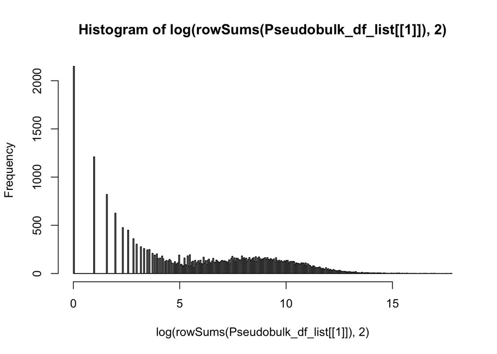

```r
hist(log(rowSums(Pseudobulk_df_list[[1]]),2), breaks = 500) #checking distribution of clusters
```

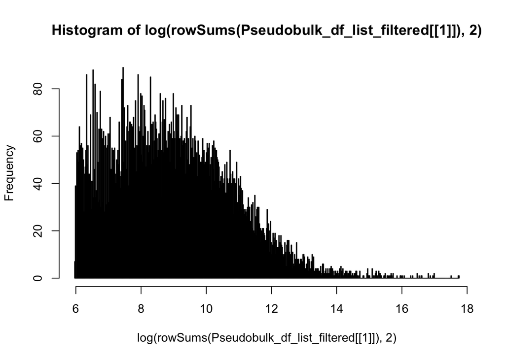

```r
# Filter Based of Thresholds
rowSum_threshold <- 64
colSum_threshold <- 1000
Pseudobulk_df_list_filtered <- list(NA)
for (cluster in 0:num_clusters){
  chosen_cluster<-Pseudobulk_df_list[[cluster+1]]
  chosen_cluster <- chosen_cluster %>% filter(rowSums(chosen_cluster)>=rowSum_threshold)
  chosen_cluster <- chosen_cluster[,colSums(chosen_cluster)>colSum_threshold]
  Pseudobulk_df_list_filtered[[cluster+1]] <- chosen_cluster}

#checking distribution again
hist(log(rowSums(Pseudobulk_df_list_filtered[[1]]),2), breaks = 500)
```

```r
dim(Pseudobulk_df_list_filtered[[1]])
```

```
## [1] 15523   589
```

```r
# Normalizing
Pseudobulk_df_list_normalised <- list(NA)
for (cluster in 0:num_clusters){
  chosen_cluster <- Pseudobulk_df_list_filtered[[cluster+1]]
  chosen_cluster <- betweenLaneNormalization(as.matrix(chosen_cluster), which="full",offset=FALSE, round=TRUE)
  Pseudobulk_df_list_normalised[[cluster+1]] <- chosen_cluster}
```

```r
# Assess Dimensions
num_genes <- c()
num_ecotypes <- c()

for (cluster in 0:num_clusters){
  chosen_cluster <- Pseudobulk_df_list_filtered[[cluster+1]]
  num_genes[cluster+1] <- nrow(chosen_cluster)
  num_ecotypes[cluster+1] <- ncol(chosen_cluster)}

Cluster_dims <- data.frame(num_genes, num_ecotypes)
Cluster_dims
```

```
##    num_genes num_ecotypes
## 1      15523          589
## 2      12072          564
## 3      13453          665
## 4      12605          562
## 5      12780          651
## 6      11045          482
## 7      10857          501
## 8      10450          524
## 9      10539          478
## 10      9499          504
## 11      9018          434
## 12      8861          488
## 13      8403          441
## 14      6112          305
## 15      6021          284
## 16      6502          336
## 17      5853          306
## 18      3545          211
## 19      2488          141
```

# Regression - Calling R and P

```r
#can access google sheet with links to all phenotypes here: https://docs.google.com/spreadsheets/d/1J2yd9iQaU8BcKkSKplbYVYeoX4OHkqAH5jX0_Hf8JhE/edit?usp=sharing
setwd("/Users/tanvijain/Documents/EckerLab/Phenotypes/")
Latitude <- read.csv("Latitude_Pheno.csv")
FloweringTime_Phenotype <- read.csv("FloweringTimePhenotype.csv")
StomataDensity_Phenotype <- read.csv("StomataDensityPheno.csv")
PlantDryWeight_Phenotype <- read.csv("PlantDryWeightPhenotype.csv")
StomataSize_Phenotype <- read.csv("StomataSizePheno.csv")
ZincConc_Phenotype <- read.csv("ZincConcentrationPhenotype.csv") #doesn't work
RootGrowthRateC_Phenotype <- read.csv("P2RootGrowthControl_Phenotype.csv")
RootGrowthRateABA_Phenotype <- read.csv("P2RootGrowthABA_Phenotype.csv")
SurvivalFruitTLP_Phenotype <- read.csv("rSurvivalFruitTlp_Phenotype.csv") #relative survival to reproduction (proportion of plants or 1/0 alive/dead) in Tuebingen low precipitation treatment and population (high density) replicate
Mean_P2_ABA <- read.csv("Mean_P2_ABA.csv")
Mean_TRL_C <- read.csv("https://arapheno.1001genomes.org/rest/phenotype/359/values.csv")
Mean_TLRL_C <- read.csv("https://arapheno.1001genomes.org/rest/phenotype/358/values.csv")
Mean_R_C <- read.csv("https://arapheno.1001genomes.org/rest/phenotype/352/values.csv")
Mean_P2_C <- read.csv("https://arapheno.1001genomes.org/rest/phenotype/355/values.csv")

Mean_LRR_C <- read.csv("https://arapheno.1001genomes.org/rest/phenotype/360/values.csv")
Mean_LRL_C <- read.csv("https://arapheno.1001genomes.org/rest/phenotype/353/values.csv")
Mean_LRDR_C <- read.csv("https://arapheno.1001genomes.org/rest/phenotype/357/values.csv")
Mean_LRDP_C <- read.csv("https://arapheno.1001genomes.org/rest/phenotype/356/values.csv")
Mean_LRno_C <- read.csv("https://arapheno.1001genomes.org/rest/phenotype/354/values.csv")
```

```r
#calculating the difference between Mean_P2_ABA and control
for (accession in Mean_P2_ABA$accession_id){
  if (sum(is.na.data.frame(Mean_P2_C[accession,]))==0){
    difference = Mean_P2_ABA[accession, 'phenotype_value'] - Mean_P2_C[accession, 'phenotype_value']
    Mean_P2_ABA[accession, 'phenotype_value'] <- difference
  } else {
    Mean_P2_ABA[accession, 'phenotype_value'] <- NA
  }
}
Mean_P2_ABA <- Mean_P2_ABA[rowSums(is.na(Mean_P2_ABA)) != ncol(Mean_P2_ABA),]
```

```r
# Input phenotype here
Chosen_Phenotype<- FloweringTime_Phenotype


# Subset Each Pseudo-Bulk Cluster By Phenotype Availability
Phenotype_List<-list(NA)
Cluster_List<-list(NA)

 for (i in 0:num_clusters){

  chosen_cluster_df <- Pseudobulk_df_list_normalised[[i+1]]

  # Intersect
  colnames(chosen_cluster_df) <- as.numeric(str_remove(colnames(chosen_cluster_df),"_"))
  Common_Accessions <- intersect(Chosen_Phenotype[,2],colnames(chosen_cluster_df))

  # Filter
  phenotype_mod <- Chosen_Phenotype[Chosen_Phenotype$accession_id %in% Common_Accessions,]  # filtering out accessions from phenotype df not found in our data
  phenotype_mod <- phenotype_mod[order(phenotype_mod$accession_id, decreasing=FALSE),] # sorting accession ID in ascending order
  phenotype_mod<- phenotype_mod[!duplicated(phenotype_mod$accession_id),] # if there are duplicate measurements, remove them

  cluster_mod <- chosen_cluster_df[,Common_Accessions]
  cluster_mod <- cluster_mod[, order(as.integer(colnames(cluster_mod)))]

  Phenotype_List[[i+1]] <- phenotype_mod
  Cluster_List[[i+1]]   <- cluster_mod  }

# Get Regression and p-value
regression_df_list <- list(NA)


for (b in 0:num_clusters){
  print(b)
  phenotype_mod <- Phenotype_List[[b+1]]
  cluster_mod <- Cluster_List[[b+1]]
  print(summary(phenotype_mod$accession_id == as.numeric(colnames(cluster_mod)))) # just check all aligned, cause if not we have massive problems!
  r_val<-NA
  p_val<-NA
  for (a in 1:nrow(cluster_mod)){
    ####
    if (sum(cluster_mod[a,])==0){
      r_val[a] <- 0
      next
    }
    ####
    r_val[a] <- as.numeric(cor.test(as.numeric(cluster_mod[a,]),phenotype_mod$phenotype_value)[4])} #put logistic reg here
  for (a in 1:nrow(cluster_mod)){
    ####
    if (sum(cluster_mod[a,])==0){
      p_val[a] <- NA
      next
    }
    p_val[a] <- as.numeric(cor.test(as.numeric(cluster_mod[a,]),phenotype_mod$phenotype_value)[3])}

  output<-as.data.frame(cbind(r_val,p.adjust(p_val)))
  output[,3]<-rownames(cluster_mod)
  colnames(output)<-c("R_value","P_adj","Gene")
  rownames(output)<-output$Gene
  output<-subset(output, output$P_adj<0.01)
  regression_df_list[[b+1]]<-output }
```

```
## [1] 0
##    Mode    TRUE
## logical     526
## [1] 1
##    Mode    TRUE
## logical     504
## [1] 2
##    Mode    TRUE
## logical     600
## [1] 3
##    Mode    TRUE
## logical     500
## [1] 4
##    Mode    TRUE
## logical     586
## [1] 5
##    Mode    TRUE
## logical     426
## [1] 6
##    Mode    TRUE
## logical     443
## [1] 7
##    Mode    TRUE
## logical     466
## [1] 8
##    Mode    TRUE
## logical     419
## [1] 9
##    Mode    TRUE
## logical     451
## [1] 10
##    Mode    TRUE
## logical     388
## [1] 11
##    Mode    TRUE
## logical     434
## [1] 12
##    Mode    TRUE
## logical     395
## [1] 13
##    Mode    TRUE
## logical     266
## [1] 14
##    Mode    TRUE
## logical     247
## [1] 15
##    Mode    TRUE
## logical     294
## [1] 16
##    Mode    TRUE
## logical     267
## [1] 17
##    Mode    TRUE
## logical     181
## [1] 18
##    Mode    TRUE
## logical     126
```

# Regression - Consolidating Clusters into Matrix

```r
# creating a list of all genes in all clusters to make common table
union_genes<-NA
for (i in 0:num_clusters) {union_genes<-c(union_genes,regression_df_list[[i+1]][,3])}
union_genes<-unique(union_genes[-1])

consolidated_matrix<-matrix(NA, nrow  = length(union_genes), ncol = num_clusters+1)
rownames(consolidated_matrix)<-union_genes
colnames(consolidated_matrix)<-c(0:num_clusters)

for (a in 1:length(consolidated_matrix[1,])){
cluster_chosen<-regression_df_list[[a]]
for (i in 1:length(consolidated_matrix[,1])) { consolidated_matrix[i,a]<- ifelse(rownames(consolidated_matrix)[i] %in% cluster_chosen$Gene, cluster_chosen[rownames(consolidated_matrix)[i],1], NA) }}
```

```r
head(consolidated_matrix)
```

```
##                    0  1  2  3  4          5  6  7  8  9 10 11 12 13 14 15 16 17
## AT1G03080 -0.2189041 NA NA NA NA         NA NA NA NA NA NA NA NA NA NA NA NA NA
## AT1G07110 -0.2266944 NA NA NA NA -0.2498483 NA NA NA NA NA NA NA NA NA NA NA NA
## AT1G07990 -0.2546194 NA NA NA NA         NA NA NA NA NA NA NA NA NA NA NA NA NA
## AT1G08260 -0.2211574 NA NA NA NA         NA NA NA NA NA NA NA NA NA NA NA NA NA
## AT1G10760 -0.2349542 NA NA NA NA         NA NA NA NA NA NA NA NA NA NA NA NA NA
## AT1G14650 -0.2688846 NA NA NA NA         NA NA NA NA NA NA NA NA NA NA NA NA NA
##           18
## AT1G03080 NA
## AT1G07110 NA
## AT1G07990 NA
## AT1G08260 NA
## AT1G10760 NA
## AT1G14650 NA
```

# Heatmap

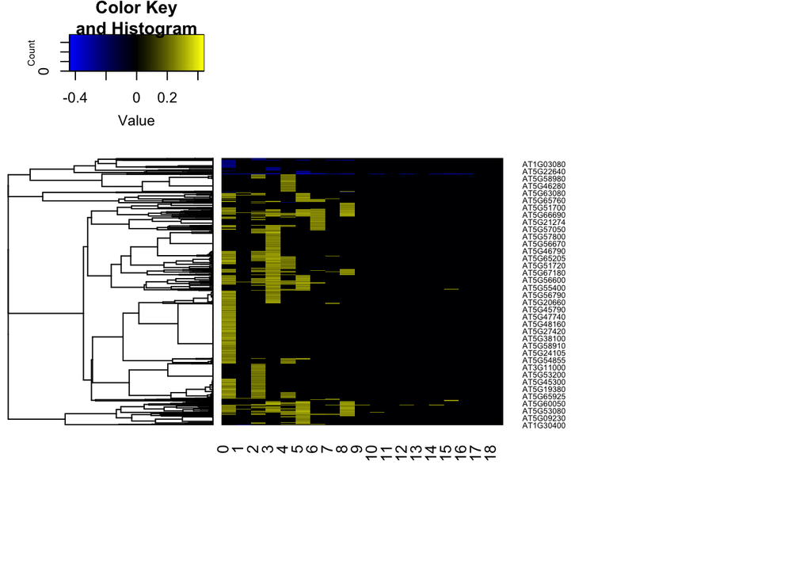

```r
#creating heatmap after subsetting genes
my_palette <- colorRampPalette(c("blue", "black", "yellow"))(n = 100)
to_heatmap <- consolidated_matrix
to_heatmap [is.na(to_heatmap )]<-0
to_heatmap <-as.matrix(to_heatmap )
if (nrow(consolidated_matrix)>=2){
heatmap.2(to_heatmap , Rowv=as.dendrogram(hclust(as.dist(1-cor(t(to_heatmap ), method="pearson")), method="complete")),
          Colv=NA,dendrogram="row", scale="none", col=my_palette, tracecol=NA,margins = c(8, 16))
} else{
  consolidated_matrix
}
```

```r
cat(noquote(rownames(consolidated_matrix)),fill=TRUE)
```

[output not shown]

[output cut: 212 more lines]

[output not shown]

# Scatterplot (updated)

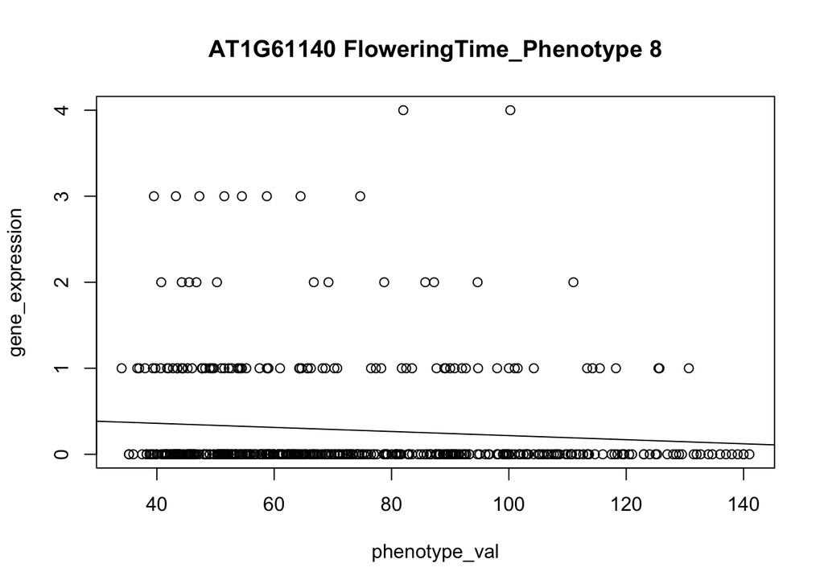

```
## integer(0)
```

```r
# Scatter plot for each gene
gene <- 'AT1G61140'
cluster_num <- 8
Phenotype_name <- "FloweringTime_Phenotype"
chosen_cluster_df <- Pseudobulk_df_list_normalised[[cluster_num]] # choose cluster
phenotype_df <- Chosen_Phenotype # phenotype defined above
colnames(chosen_cluster_df) <- as.numeric(str_remove(colnames(chosen_cluster_df),"_"))
  Common_Accessions <- intersect(Chosen_Phenotype[,2],colnames(chosen_cluster_df))

  # Filter
  phenotype_mod <- Chosen_Phenotype[Chosen_Phenotype$accession_id %in% Common_Accessions,]  # filtering out accessions from phenotype df not found in our data
  phenotype_mod <- phenotype_mod[order(phenotype_mod$accession_id, decreasing=FALSE),] # sorting accession ID in ascending order
  phenotype_mod<- phenotype_mod[!duplicated(phenotype_mod$accession_id),] # if there are duplicate measurements, remove them

  cluster_mod <- chosen_cluster_df[,Common_Accessions]
  cluster_mod <- cluster_mod[, order(as.integer(colnames(cluster_mod)))]
phenotype_val <- as.vector(phenotype_mod$phenotype_value)
gene_expression <- cluster_mod[gene,]
gene_expression <- as.numeric(gene_expression)
plot(phenotype_val, gene_expression, main = paste(gene, Phenotype_name, cluster_num)) + abline(lm(gene_expression~phenotype_val))
```

#calculating cell specific markers % per cluster

```r
#filtering out FindAllMarkers() genes using cell specificity and pval
markers_table <- read.csv("/Users/tanvijain/Documents/EckerLab/FindAllMarkersTable.csv")
markers_table[,8] <- markers_table$pct.1/markers_table$pct.2
markers_table<-markers_table[order(markers_table$p_val_adj,decreasing = FALSE),]
markers_table <- markers_table[(markers_table$gene>1.2) & (markers_table$p_val_adj<0.01),]
markers_table[,1] <- substr(markers_table[,1], 1, 9)
markers_table <- markers_table[markers_table$X %in% unique(markers_table[,1]),]

melt_markers <- melt(markers_table[,c(1,7)], id="cluster")
cell_specific_num <- matrix(NA, nrow=19, ncol=3)
for (i in 1:19){
  cell_specific_i <- melt_markers[melt_markers$cluster==i,3]
  corr_gene_i <- rownames(consolidated_matrix[!is.na(consolidated_matrix[,i]),])
  #overlapping genes between FindAllMarkers and consolidated matrix in each cluster
  cell_specific_num[i,1] <- length(intersect(cell_specific_i,corr_gene_i))
  cell_specific_num[i,2] <- sum(!is.na(consolidated_matrix[,i]))
  cell_specific_num[i,3] <- cell_specific_num[i,1]/cell_specific_num[i,2]
}
colnames(cell_specific_num) <- c("num_cell_specific_genes","num_genes","cell_specific_%")

#markers <- capture.output(cat(unique(markers), fill=FALSE, sep = "\n"))
#writeLines(markers, "/Users/tanvijain/Documents/EckerLab/FindAllMarkersSorted.txt")
```

```r
cell_specific_num
```

```
##       num_cell_specific_genes num_genes cell_specific_%
##  [1,]                      17      1278     0.013302034
##  [2,]                       1        38     0.026315789
##  [3,]                      29       688     0.042151163
##  [4,]                      68       818     0.083129584
##  [5,]                      18       518     0.034749035
##  [6,]                       8       481     0.016632017
##  [7,]                       2       247     0.008097166
##  [8,]                       0        43     0.000000000
##  [9,]                       9       299     0.030100334
## [10,]                       0         2     0.000000000
## [11,]                       0         4     0.000000000
## [12,]                       0         1     0.000000000
## [13,]                       0         6     0.000000000
## [14,]                       0         0             NaN
## [15,]                       0         3     0.000000000
## [16,]                       0        14     0.000000000
## [17,]                       0         2     0.000000000
## [18,]                       0         0             NaN
## [19,]                       0         0             NaN
```